# dplyr

Chris

10/30/2019

- [Documentation](https://www.rdocumentation.org/packages/dplyr/versions/0.7.8)
- [Cheat sheet](https://rstudio.com/wp-content/uploads/2015/02/data-wrangling-cheatsheet.pdf)

## Formatting Data

```r
expression.data <- read.delim("DPLYR_EXPRESSION_DATA.tsv")
head(colnames(expression.data))
```

```
## [1] "YPD1" "YPD2" "YPD3" "YPD4" "YPD5" "YPD6"
```

```r
head(rownames(expression.data))
```

```
## [1] "YDL248W"   "YDL247W.A" "YDL247W"   "YDL246C"   "YDL245C"   "YDL244W"
```

```r
# Looks like this data is genes in rows and biological samples in columns
```

All the metadata (non-expression data containing information about the biological samples) is in a separate file. This is common.

```r
meta.data <- read.delim("DPLYR_SAMPLE_DATA.tsv")
str(meta.data)
```

```
## 'data.frame':    140 obs. of  3 variables:
##  $ Sample_ID : Factor w/ 140 levels "RAPA1","RAPA10",..: 71 82 93 104 115 126 137 139 140 72 ...
##  $ Experiment: Factor w/ 2 levels "RAPA","YPD": 2 2 2 2 2 2 2 2 2 2 ...
##  $ TF        : Factor w/ 12 levels "dal80","dal81",..: 12 12 12 12 12 12 1 1 1 1 ...
```

```r
summary(meta.data)
```

```
##    Sample_ID   Experiment       TF
##  RAPA1  :  1   RAPA:70    dal80  :12
##  RAPA10 :  1   YPD :70    dal81  :12
##  RAPA11 :  1              dal82  :12
##  RAPA12 :  1              gat1   :12
##  RAPA13 :  1              gcn4   :12
##  RAPA14 :  1              gln3   :12
##  (Other):134              (Other):68
```

Let’s convert from total transcript counts to TPM (Transcripts Per Million Transcripts).

```r
print("Counts per experiment:")
```

```
## [1] "Counts per experiment:"
```

```r
print(colSums(expression.data))
```

```
##   YPD1   YPD2   YPD3   YPD4   YPD5   YPD6   YPD7   YPD8   YPD9  YPD10
## 454811 495919 172713 496034 475379 345509 424572 449862 423196 397263
##  YPD11  YPD12  YPD13  YPD14  YPD15  YPD16  YPD17  YPD18  YPD19  YPD20
## 386366 409580 342492 371585 342606 313185 407453 357315 484012 498667
##  YPD21  YPD22  YPD23  YPD24  YPD25  YPD26  YPD27  YPD28  YPD29  YPD30
## 480684 377768 490755 481425 488144 478929 463758 398809 482775 477314
##  YPD31  YPD32  YPD33  YPD34  YPD35  YPD36  YPD37  YPD38  YPD39  YPD40
## 257716 247995 200750 250387 252108 288415 102986  97536  59957 115236
##  YPD41  YPD42  YPD43  YPD44  YPD45  YPD46  YPD47  YPD48  YPD49  YPD50
##  79160 136377 516989 435418 476518 477056 446642 511190 404895 293644
##  YPD51  YPD52  YPD53  YPD54  YPD55  YPD56  YPD57  YPD58  YPD59  YPD60
## 327578 307130 375551 364459 300065 390396 368799 359600 331388 346100
##  YPD61  YPD62  YPD63  YPD64  YPD65  YPD66  YPD67  YPD68  YPD69  YPD70
## 647201 620678 718585 620967 749705 660715 354758 577719 563310 561610
##  RAPA1  RAPA2  RAPA3  RAPA4  RAPA5  RAPA6  RAPA7  RAPA8  RAPA9 RAPA10
## 349371 433712 199840 341923 385057 311913 362597 415682 379206 425042
## RAPA11 RAPA12 RAPA13 RAPA14 RAPA15 RAPA16 RAPA17 RAPA18 RAPA19 RAPA20
## 405551 403280 281071 296424 230358 204063 348117 228027 405913 415026
## RAPA21 RAPA22 RAPA23 RAPA24 RAPA25 RAPA26 RAPA27 RAPA28 RAPA29 RAPA30
## 376209 400097 435764 397367 446309 480512 458013 519754 390268 437755
## RAPA31 RAPA32 RAPA33 RAPA34 RAPA35 RAPA36 RAPA37 RAPA38 RAPA39 RAPA40
## 193559 163441 196014 202612 176981 231672 224791 241708 187714 226455
## RAPA41 RAPA42 RAPA43 RAPA44 RAPA45 RAPA46 RAPA47 RAPA48 RAPA49 RAPA50
## 187970 307028 462613 423977 371124 377402 431714 411160 402790 316059
## RAPA51 RAPA52 RAPA53 RAPA54 RAPA55 RAPA56 RAPA57 RAPA58 RAPA59 RAPA60
## 477002 432187 385761 402435 386466 397260 466171 420249 446830 407190
## RAPA61 RAPA62 RAPA63 RAPA64 RAPA65 RAPA66 RAPA67 RAPA68 RAPA69 RAPA70
## 442911 453103 560391 582004 661425 594198 319460 519435 530162 488198
```

```r
expression.data.normalized <- sweep(expression.data, 2, colSums(expression.data), FUN = "/") * 1e6
print(colSums(expression.data.normalized))
```

```
##   YPD1   YPD2   YPD3   YPD4   YPD5   YPD6   YPD7   YPD8   YPD9  YPD10
##  1e+06  1e+06  1e+06  1e+06  1e+06  1e+06  1e+06  1e+06  1e+06  1e+06
##  YPD11  YPD12  YPD13  YPD14  YPD15  YPD16  YPD17  YPD18  YPD19  YPD20
##  1e+06  1e+06  1e+06  1e+06  1e+06  1e+06  1e+06  1e+06  1e+06  1e+06
##  YPD21  YPD22  YPD23  YPD24  YPD25  YPD26  YPD27  YPD28  YPD29  YPD30
##  1e+06  1e+06  1e+06  1e+06  1e+06  1e+06  1e+06  1e+06  1e+06  1e+06
##  YPD31  YPD32  YPD33  YPD34  YPD35  YPD36  YPD37  YPD38  YPD39  YPD40
##  1e+06  1e+06  1e+06  1e+06  1e+06  1e+06  1e+06  1e+06  1e+06  1e+06
##  YPD41  YPD42  YPD43  YPD44  YPD45  YPD46  YPD47  YPD48  YPD49  YPD50
##  1e+06  1e+06  1e+06  1e+06  1e+06  1e+06  1e+06  1e+06  1e+06  1e+06
##  YPD51  YPD52  YPD53  YPD54  YPD55  YPD56  YPD57  YPD58  YPD59  YPD60
##  1e+06  1e+06  1e+06  1e+06  1e+06  1e+06  1e+06  1e+06  1e+06  1e+06
##  YPD61  YPD62  YPD63  YPD64  YPD65  YPD66  YPD67  YPD68  YPD69  YPD70
##  1e+06  1e+06  1e+06  1e+06  1e+06  1e+06  1e+06  1e+06  1e+06  1e+06
##  RAPA1  RAPA2  RAPA3  RAPA4  RAPA5  RAPA6  RAPA7  RAPA8  RAPA9 RAPA10
##  1e+06  1e+06  1e+06  1e+06  1e+06  1e+06  1e+06  1e+06  1e+06  1e+06
## RAPA11 RAPA12 RAPA13 RAPA14 RAPA15 RAPA16 RAPA17 RAPA18 RAPA19 RAPA20
##  1e+06  1e+06  1e+06  1e+06  1e+06  1e+06  1e+06  1e+06  1e+06  1e+06
## RAPA21 RAPA22 RAPA23 RAPA24 RAPA25 RAPA26 RAPA27 RAPA28 RAPA29 RAPA30
##  1e+06  1e+06  1e+06  1e+06  1e+06  1e+06  1e+06  1e+06  1e+06  1e+06
## RAPA31 RAPA32 RAPA33 RAPA34 RAPA35 RAPA36 RAPA37 RAPA38 RAPA39 RAPA40
##  1e+06  1e+06  1e+06  1e+06  1e+06  1e+06  1e+06  1e+06  1e+06  1e+06
## RAPA41 RAPA42 RAPA43 RAPA44 RAPA45 RAPA46 RAPA47 RAPA48 RAPA49 RAPA50
##  1e+06  1e+06  1e+06  1e+06  1e+06  1e+06  1e+06  1e+06  1e+06  1e+06
## RAPA51 RAPA52 RAPA53 RAPA54 RAPA55 RAPA56 RAPA57 RAPA58 RAPA59 RAPA60
##  1e+06  1e+06  1e+06  1e+06  1e+06  1e+06  1e+06  1e+06  1e+06  1e+06
## RAPA61 RAPA62 RAPA63 RAPA64 RAPA65 RAPA66 RAPA67 RAPA68 RAPA69 RAPA70
##  1e+06  1e+06  1e+06  1e+06  1e+06  1e+06  1e+06  1e+06  1e+06  1e+06
```

Excellent; now each experiment has the same depth. Trying to make a readable heatmap with 140 biological samples x 6000 genes will be a nightmare though. Instead I want to collapse all of the replicates for each TF/Experiment pair into a set of summary statistics.

Lets start by putting the meta data and the expression data together.

```r
# The expression data set needs to be biolgical samples x genes for this to work...

# Lets rotate the data frame and then put the Sample_ID into a column (instead of row names)
expression.data.normalized %>%
  t() %>%
  as.data.frame() %>%
  dplyr::mutate(Sample_ID = as.factor(rownames(.))) -> expression.data.normalized

# Now we can use `join` to attach the meta data
# This could be part of the same piped expression as above
# Separating long pipes for readability is sometimes helpful though
expression.data.normalized %>%
  dplyr::left_join(meta.data, by="Sample_ID") -> expression.data.normalized
```

Much better. Now all the data is in one big data frame. Lets calculate the mean.

```r
expression.data.normalized %>%
  dplyr::select(-Sample_ID) %>%
  dplyr::group_by(Experiment, TF) %>%
  dplyr::summarise_all("mean") -> mean.expression
```

Lets normalize to the control sample (WT in YPD)

```r
mean.expression %>%
  filter(TF == "WT" & Experiment == "YPD") -> control.mean

mean.expression %>%
  dplyr::mutate_at(vars(-TF, -Experiment), funs(. / control.mean$.)) -> mean.normalized.expression
```

Well that was pretty easy - lot of NAs and INFs in this data though (dividing by 0 is a problem, isn’t it)

```r
# This is easy enough to clean out by just omitting columns where the control mean was 0
mean.normalized.expression <- mean.normalized.expression[, as.vector(control.mean !=0)]
```

## Heatmap

Lets put this into a heatmap

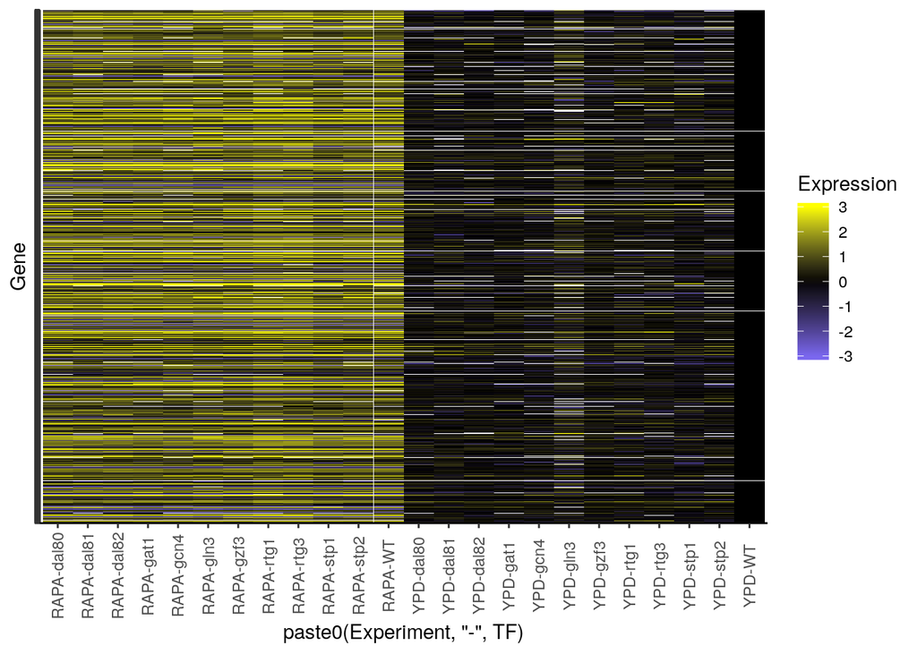

```r
ggplot2::theme_set(theme_classic())

# Lets melt, log-transform, and pipe the data into ggplot
mean.normalized.expression %>%
  reshape2::melt(id.vars=c("TF", "Experiment"), value.name="Expression", variable.name="Gene") %>%
  dplyr::mutate(Expression = log2(Expression)) %>%
  ggplot(aes(x=paste0(Experiment,"-",TF), y=Gene, fill=Expression)) -> heatmap.plt

# Now we can add geometries and layout to the data no problem
heatmap.plt +
  geom_tile() +
  scale_fill_gradient2(low='slateblue2', mid='black', high='yellow', limits=c(-3, 3), oob=squish, na.value="white") +
  theme(axis.text.y = element_blank(),
        axis.text.x = element_text(angle=90, hjust=0.5, vjust=0.5))
```

Well that was quite easy. Lets work on making this better (and doing some different analysis…)